# Exploring Ford GoBike Data 2019

## Preliminary Wrangling

Ford GoBike was a regional public bicycle sharing system in California's San Francisco Bay Area, operated by Ford Motor Company from 2017 to 2019 [1]. Ford GoBike System Data 2019 includes information about individual rides made in this bike sharing program in February 2019.

```python
# import all packages and set plots to be embedded inline
import numpy as np
import pandas as pd
import matplotlib.pyplot as plt
import seaborn as sb

%matplotlib inline
```

```python
# load in the dataset into a pandas dataframe, print statistics
tripdata = pd.read_csv('201902-fordgobike-tripdata.csv')
```

```python
# high-level overview of data shape and composition
print(tripdata.shape)
print(tripdata.dtypes)
print(tripdata.head(5))
```

```
(183412, 16)
duration_sec                 int64
start_time                  object
end_time                    object
start_station_id           float64
start_station_name          object
start_station_latitude     float64
start_station_longitude    float64
end_station_id             float64
end_station_name            object
end_station_latitude       float64
end_station_longitude      float64
bike_id                      int64
user_type                   object
member_birth_year          float64
member_gender               object
bike_share_for_all_trip     object
dtype: object
   duration_sec                start_time                  end_time  \
0         52185  2019-02-28 17:32:10.1450  2019-03-01 08:01:55.9750
1         42521  2019-02-28 18:53:21.7890  2019-03-01 06:42:03.0560
2         61854  2019-02-28 12:13:13.2180  2019-03-01 05:24:08.1460
3         36490  2019-02-28 17:54:26.0100  2019-03-01 04:02:36.8420
4          1585  2019-02-28 23:54:18.5490  2019-03-01 00:20:44.0740

   start_station_id                                start_station_name  \
0              21.0  Montgomery St BART Station (Market St at 2nd St)
1              23.0                     The Embarcadero at Steuart St
2              86.0                           Market St at Dolores St
3             375.0                           Grove St at Masonic Ave
4               7.0                               Frank H Ogawa Plaza

   start_station_latitude  start_station_longitude  end_station_id  \
0               37.789625              -122.400811            13.0
1               37.791464              -122.391034            81.0
2               37.769305              -122.426826             3.0
3               37.774836              -122.446546            70.0
4               37.804562              -122.271738           222.0

                               end_station_name  end_station_latitude  \
0                Commercial St at Montgomery St             37.794231
1                            Berry St at 4th St             37.775880
2  Powell St BART Station (Market St at 4th St)             37.786375
3                        Central Ave at Fell St             37.773311
4                         10th Ave at E 15th St             37.792714

   end_station_longitude  bike_id   user_type  member_birth_year  \
0            -122.402923     4902    Customer             1984.0
1            -122.393170     2535    Customer                NaN
2            -122.404904     5905    Customer             1972.0
3            -122.444293     6638  Subscriber             1989.0
4            -122.248780     4898  Subscriber             1974.0

  member_gender bike_share_for_all_trip
0          Male                      No
1           NaN                      No
2          Male                      No
3         Other                      No
4          Male                     Yes
```

```python
# check the dataset for null values
tripdata.isnull().sum()
```

```
duration_sec                  0
start_time                    0
end_time                      0
start_station_id            197
start_station_name          197
start_station_latitude        0
start_station_longitude       0
end_station_id              197
end_station_name            197
end_station_latitude          0
end_station_longitude         0
bike_id                       0
user_type                     0
member_birth_year          8265
member_gender              8265
bike_share_for_all_trip       0
dtype: int64
```

The statistics of null values show that when member_gender values are missing, member_birth_year values are missing too. I will keep the null values as is for now as I don't want to lose over 8000 data by simply dropping the rows with null values.

```python
# copy the original dataset for performing data wrangling
# this is a safety measure so that we don't lose any original data
td_clean = tripdata.copy()
```

```python
# convert 'duration_sec' to duration_min'
# this is not a quality of tidiness issue
# this is done to make the exploration easy to comprehend
td_clean['duration_min'] = (td_clean['duration_sec'] / 60).round(2)
```

```python
# extract days from the 'start_time' column to create a 'start_time_day' column
td_clean['start_time_day'] = pd.to_datetime(td_clean['start_time']).dt.strftime('%A')
# extract hours from the 'start_time' column to create a 'start_time_hour' column
td_clean['start_time_hour'] = pd.to_datetime(td_clean['start_time']).dt.hour
# extract hours from the 'end_time' column to create a 'end_time_hour' column
td_clean['end_time_hour'] = pd.to_datetime(td_clean['end_time']).dt.hour
```

```python
# calculate age of the members from 'member_birth_year' column
td_clean['age'] = 2019 - td_clean['member_birth_year']
```

I first converted the null values in the 'age' column to 0. However, it created an issue later with the visualization and log-scale plotting. Therefore, it's better to keep them as they are.

```python
# replace null values with 'None' in 'member_gender' column
td_clean['member_gender'] = td_clean['member_gender'].astype(object).where(pd.notnull(td_clean['member_gender']), None)
```

```python
# fix the data types for the following columns
td_clean['start_station_id'] = td_clean['start_station_id'].astype(str)
td_clean['end_station_id'] = td_clean['end_station_id'].astype(str)
td_clean['bike_id'] = td_clean['bike_id'].astype(str)
```

```python
# drop unwanted columns
td_clean.drop(axis=1, columns=['duration_sec', 'start_time', 'end_time', 'member_birth_year'], inplace=True)
```

```python
# high-level overview of data shape and composition of 'td_clean' dataframe
print(td_clean.shape)
print(td_clean.dtypes)
print(td_clean.head(5))
```

```
(183412, 17)
start_station_id            object
start_station_name          object
start_station_latitude     float64
start_station_longitude    float64
end_station_id              object
end_station_name            object
end_station_latitude       float64
end_station_longitude      float64
bike_id                     object
user_type                   object
member_gender               object
bike_share_for_all_trip     object
duration_min               float64
start_time_day              object
start_time_hour              int64
end_time_hour                int64
age                        float64
dtype: object
  start_station_id                                start_station_name  \
0             21.0  Montgomery St BART Station (Market St at 2nd St)
1             23.0                     The Embarcadero at Steuart St
2             86.0                           Market St at Dolores St
3            375.0                           Grove St at Masonic Ave
4              7.0                               Frank H Ogawa Plaza

   start_station_latitude  start_station_longitude end_station_id  \
0               37.789625              -122.400811           13.0
1               37.791464              -122.391034           81.0
2               37.769305              -122.426826            3.0
3               37.774836              -122.446546           70.0
4               37.804562              -122.271738          222.0

                               end_station_name  end_station_latitude  \
0                Commercial St at Montgomery St             37.794231
1                            Berry St at 4th St             37.775880
2  Powell St BART Station (Market St at 4th St)             37.786375
3                        Central Ave at Fell St             37.773311
4                         10th Ave at E 15th St             37.792714

   end_station_longitude bike_id   user_type member_gender  \
0            -122.402923    4902    Customer          Male
1            -122.393170    2535    Customer          None
2            -122.404904    5905    Customer          Male
3            -122.444293    6638  Subscriber         Other
4            -122.248780    4898  Subscriber          Male

  bike_share_for_all_trip  duration_min start_time_day  start_time_hour  \
0                      No        869.75       Thursday               17
1                      No        708.68       Thursday               18
2                      No       1030.90       Thursday               12
3                      No        608.17       Thursday               17
4                     Yes         26.42       Thursday               23

   end_time_hour   age
0              8  35.0
1              6   NaN
2              5  47.0
3              4  30.0
4              0  45.0
```

```python
# descriptive statistics for numeric variables
print(td_clean.describe())
```

```
       start_station_latitude  start_station_longitude  end_station_latitude  \
count           183412.000000            183412.000000         183412.000000
mean                37.771223              -122.352664             37.771427
std                  0.099581                 0.117097              0.099490
min                 37.317298              -122.453704             37.317298
25%                 37.770083              -122.412408             37.770407
50%                 37.780760              -122.398285             37.781010
75%                 37.797280              -122.286533             37.797320
max                 37.880222              -121.874119             37.880222

       end_station_longitude   duration_min  start_time_hour  end_time_hour  \
count          183412.000000  183412.000000    183412.000000  183412.000000
mean             -122.352250      12.101301        13.458421      13.614769
std                 0.116673      29.906501         4.724978       4.739638
min              -122.453704       1.020000         0.000000       0.000000
25%              -122.411726       5.420000         9.000000       9.000000
50%              -122.398279       8.570000        14.000000      14.000000
75%              -122.288045      13.270000        17.000000      18.000000
max              -121.874119    1424.070000        23.000000      23.000000

                 age
count  175147.000000
mean       34.193563
std        10.116689
min        18.000000
25%        27.000000
50%        32.000000
75%        39.000000
max       141.000000
```

### What is the structure of your dataset?

The dataset provides 183,412 entries of bike share statistics for various age group and customer base. The bike share schedule and pattern of the users are reflected in this data set. We have the following variables in the 17 columns.

duration_min: quantitative, continuous  
start_time & end_time: quantitative, continuous  
age: quantitative, discrete  
ids: categorical, nominal  
station names: categorical, nominal  
user_type : categorical, nominal  
member_gender: categorical, nominal  
bike_share_for_all_trip: categorical, nominal

### What is/are the main feature(s) of interest in your dataset?

I would like to examine the bikesharing pattern and schedule depending on various user types.

### What features in the dataset do you think will help support your investigation into your feature(s) of interest?

I expect age and gender of the members will play an important role determining the duration of rides. Also, timing of the trips and location would reveal some valuable information on their trip patterns.

## Univariate Exploration

In this section, I will investigate distributions of individual variables. If any unusual points or outliers are noticed, it will be examined to clean things up.  
I will start by looking at the user group—age, subscription policy, gender, and whether or not riders are enrolled in the bike share for all trip program.

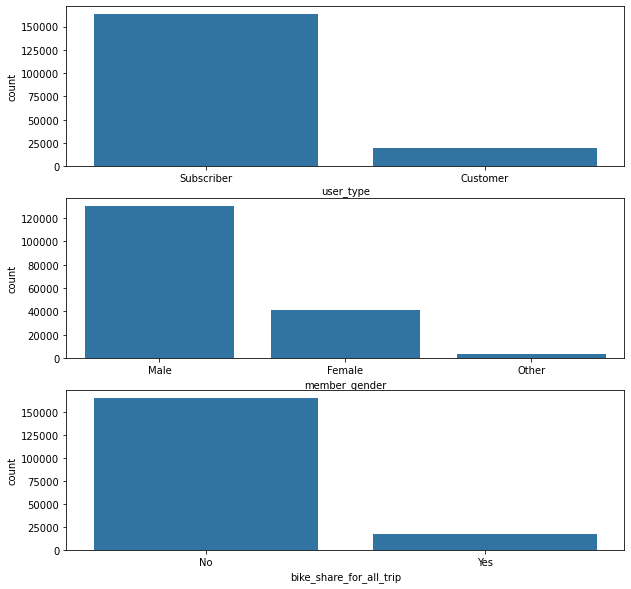

```python
# let's plot 'user_type', 'member_gender', and 'bike_share_for_all_trip' together to get an idea of each nominal variable's distribution
user_type_order = td_clean['user_type'].value_counts().index
gender_order = td_clean['member_gender'].value_counts().index
bike_share_order = td_clean['bike_share_for_all_trip'].value_counts().index

fig, ax = plt.subplots(nrows=3, figsize = [10,10])

default_color = sb.color_palette()[0]
sb.countplot(data = td_clean, x = 'user_type', color = default_color, order = user_type_order, ax = ax[0])
sb.countplot(data = td_clean, x = 'member_gender', color = default_color, order = gender_order, ax = ax[1])
sb.countplot(data = td_clean, x = 'bike_share_for_all_trip', color = default_color, order = bike_share_order, ax = ax[2])

plt.show()
```

There are 89.2% subscribed members and 10.8% causal customers.  
74.6% male, 23.3% female, and 2.1% other gender type. It looks like some members did not disclose their gender while subscribing to this program. We'll investigae this further in the Bivariate Exploration section.  
Bike share for all trip is a discounted program for the low-income community[3]. Looks like the program was not very popular among the San Franciso people. The plot shows that 90.5% bikers did not register for the bike share for all trip program; only a 9.5% did.

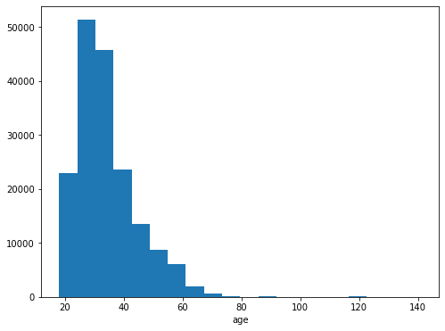

```python
# plot a histogram for age
plt.figure(figsize = [8,6])
plt.hist(data = td_clean, x = 'age', bins = 20)
plt.xlabel('age');
```

The 'age' histogram contains some outliers. Specially, members over 100 years of age are very unlikely to participate in bikesharing. It's worth taking a bit of time to identify these outliers and see if they need to be filtered out of the data.

```python
# select high outliers, using criteria eyeballed from the plots
print((td_clean['age'] > 100).sum())
```

```
72
```

There are 72 rows with member age over 100. It is very difficult to examine all 72 rows to determine the accuracy of the data. Therefore, we will only consider members with less than 100 years in our next explorations.

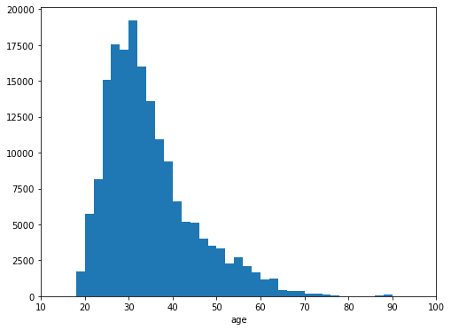

```python
# plot 'age' histogram with dynamic bin size
# apply axis limit
plt.figure(figsize=[8, 6])
bins = np.arange(10, 100+2, 2)
plt.hist(data = td_clean, x = 'age', bins = bins)
plt.xlim(10, 100)
ticks = [10, 20, 30, 40 , 50, 60, 70, 80, 90, 100]
labels = ['{}'.format(val) for val in ticks]
plt.xticks(ticks, labels)
plt.xlabel('age');
```

The histogram is unimodal and right skewed. Around 75% of riders are under 40 years of age. With age, the bikeshare-usage decreases in numbers, as expected. The plot has a long tail of points with large values. If we apply a logarithmic transform to the data, the data will follow a normal distribution.

```python
# preparatory steps
df_age = td_clean.loc[td_clean['age']<100]
# transform the describe() to a scale of log10
np.log10(df_age['age'].describe())
```

```
count    5.243224
mean     1.533502
std      0.998786
min      1.255273
25%      1.431364
50%      1.505150
75%      1.591065
max      1.995635
Name: age, dtype: float64
```

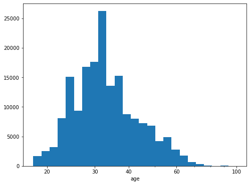

```python
# plot 'age' histogram with axis transformation
plt.figure(figsize=[8, 6])
bins = 10 ** np.arange(1.25, 2+0.03, 0.03)
plt.hist(data=df_age, x='age', bins=bins);
plt.xscale('log')
ticks = [20, 30, 40, 60, 100]
labels = ['{}'.format(v) for v in ticks]
plt.xticks(ticks, labels)
plt.xlabel('age');
```

When plotted on a log-scale, the age distribution still looks unimodal, with the peak at 32. A higher percentage of users are also noticed at 30 years and 38 years. Interestingly, after 38 years, the plot becomes gradually right-skewed till 100. It indicates that the Ford GoBike program was the most popular among the 30s adults.  
After examining the user group, we'll now move on to the bike-usage duration and schedule.

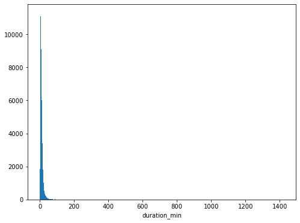

```python
# hisogram plot of duration_min
# start with a standard-scaled plot
plt.figure(figsize = [8,6])
plt.hist(data = td_clean, x = 'duration_min', bins = 2000)
plt.xlabel('duration_min');
```

From the statistics of 'duration_min' column, we see that 50% of the rides are for about 9 minutes and 75% are a little over 13 minutes. We'll limit our plot within the trips which have less than 100 minutes of duration for now.

```python
# select high outliers, using criteria eyeballed from the plots
print((td_clean['duration_min'] > 100).sum())
```

```
909
```

There are 909 entries with trip duration over 100 minutes, which is about 0.49% of the entire trip data. It is very difficult to examine each of 909 entries to find out why the inconsistancies actually occurred. Therefore, we'll consider them as outliers and avoid them in our next visualizations.

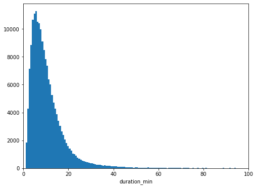

```python
# histogram plot of duration_min with a max value of 100
plt.figure(figsize = [8,6])
plt.hist(data = td_clean, x = "duration_min", bins = 2000)
plt.xlim(0, 100)
plt.xlabel('duration_min');
```

```python
# preparatory steps
df_duration_min = td_clean.loc[td_clean['duration_min']<100]
# Transform the describe() to a scale of log10
np.log10(df_duration_min['duration_min'].describe())
```

```
count    5.261270
mean     1.028635
std      0.937679
min      0.008600
25%      0.732394
50%      0.930949
75%      1.119586
max      1.999000
Name: duration_min, dtype: float64
```

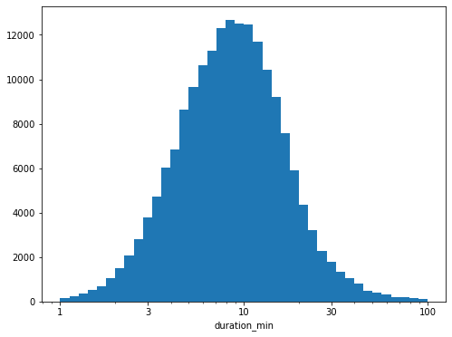

```python
# there is a long tail in the distribution, so let's put it on a log scale instead
plt.figure(figsize=[8, 6])
bins = 10 ** np.arange(0, 2+0.05, 0.05)
plt.hist(data=df_duration_min, x='duration_min', bins=bins);
plt.xscale('log')
ticks = [1, 3, 10, 30, 100]
labels = ['{}'.format(val) for val in ticks]
plt.xticks(ticks, labels)
plt.xlabel('duration_min');
```

Trip duration has a long-tailed distribution, even when we set a limit of 100. The histogram is unimodal with a peak near 9 minutes. The average trip duration is around 12 minutes. The histogram looks normal with a bell-shape.

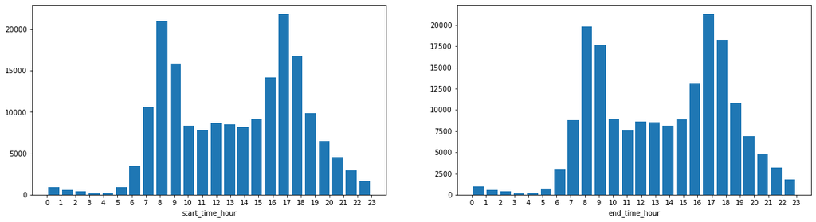

```python
# plot two histograms side by side for start_time_hour and end_time_hour
plt.figure(figsize = [20,5])
# left: start_time_hour
plt.subplot(1, 2, 1)
plt.hist(data = td_clean, x='start_time_hour', bins = 24, rwidth = 0.8);
plt.xticks(np.arange(0, 24, 1))
plt.xlabel('start_time_hour')
# right: end_time_hour
plt.subplot(1,2,2)
plt.hist(data = td_clean, x='end_time_hour', bins = 24, rwidth = 0.8);
# Display a label on the x-axis
plt.xticks(np.arange(0, 24, 1))
plt.xlabel('end_time_hour');
```

The two plots look very similar. There are spikes in 8 am and 5 pm time, generally, same to the office hours. Many riders use GoBikes to fulfill their last mile commutes to offices or universities, with ride-sharing frequency peaking between 8 am-9 am and 5 pm-6 pm.

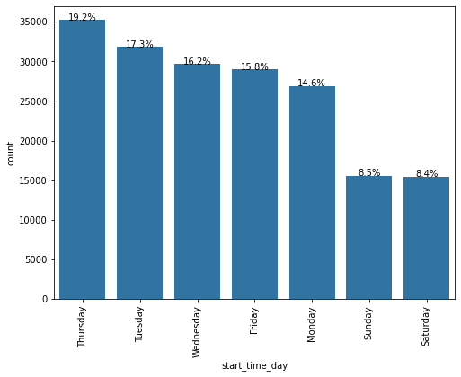

```python
# countplot of start_time_day
# preparatory steps
start_day_counts = td_clean['start_time_day'].value_counts()
n_td_clean = td_clean['start_time_day'].value_counts().sum()
# plot
plt.figure(figsize = [8,6])
start_time_day_order = td_clean['start_time_day'].value_counts().index
default_color = sb.color_palette()[0]
sb.countplot(data = td_clean, x = 'start_time_day', color = default_color, order = start_time_day_order)
# get the current tick locations and labels
locs, labels = plt.xticks(rotation=90)
# loop through each pair of locations and labels
for loc, label in zip(locs, labels):

    # get the text property for the label to get the correct count
    count = start_day_counts[label.get_text()]
    pct_string = '{:0.1f}%'.format(100*count/n_td_clean)

    # print the annotation just below the top of the bar
    plt.text(loc, count+2, pct_string, ha = 'center', color = 'black');
```

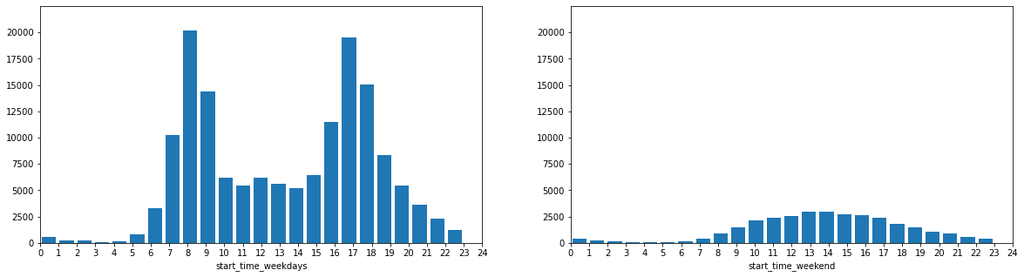

```python
# we'll now see trip frequecies by start_time_hour on weekdays and weekend
# data preparation
weekdays = td_clean.loc[td_clean['start_time_day'].isin(['Monday', 'Tuesday', 'Wednesday', 'Thursday', 'Friday'])]
weekend = td_clean.loc[td_clean['start_time_day'].isin(['Saturday', 'Sunday'])]

plt.figure(figsize = [20,5])

# left: start_time_hour for weekdays
plt.subplot(1, 2, 1)
plt.hist(data = weekdays, x='start_time_hour', bins = 24, rwidth = 0.8);
plt.xlim(0, 24)
plt.ylim(0, 22500)
plt.xticks(np.arange(0, 25, 1))
plt.yticks(np.arange(0, 22500, 2500))
plt.xlabel('start_time_weekdays')

# right: start_time_hour for weekdays
plt.subplot(1,2,2)
plt.hist(data = weekend, x='start_time_hour', bins = 24, rwidth = 0.8);
plt.xlim(0, 24)
plt.ylim(0, 22500)# y-limit is set to compare the two plots with same y-axis
plt.xticks(np.arange(0, 25, 1))
plt.yticks(np.arange(0, 22500, 2500))
plt.xlabel('start_time_weekend');
```

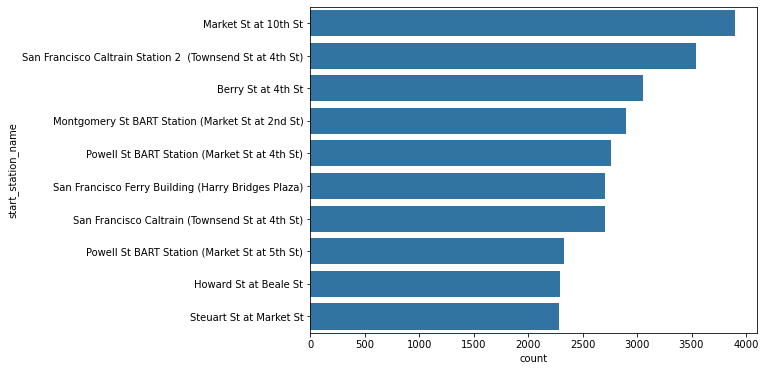

```python
# bar chart for popular start stations
# data preparation
start_station_order = td_clean.start_station_name.value_counts()[:10].index

plt.figure(figsize = [8,6])
base_color = sb.color_palette()[0]
sb.countplot(data = td_clean, y ='start_station_name', color = base_color, order = start_station_order);
```

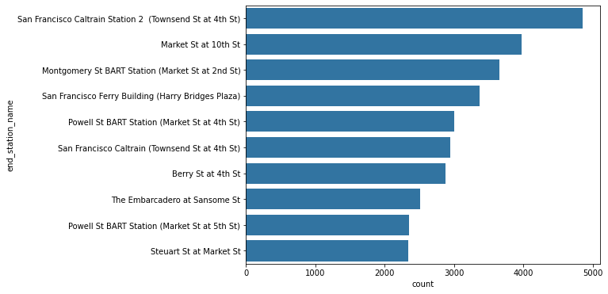

```python
# bar chart for popular end stations
# data preparation
end_station_order = td_clean.end_station_name.value_counts()[:10].index

plt.figure(figsize = [8,6])
base_color = sb.color_palette()[0]
sb.countplot(data = td_clean, y ='end_station_name', color = base_color, order = end_station_order);
```

GoBike is popular among office commuters working with tech companies like Uber, Twitter located at Market Street, San Francisco [2]. Other popular riding stations are located near major public transport hubs i.e. Caltrain Train Station, San Francisco Ferry Building (Harry Bridges Plaza) and The Embarcadero at Sansome St. The bike share system is popular among those who commute from outside of the city for work. Those that live in the city are less likely than average to be car owners. This also applies to those commuting by public transport. Moreover, the young and environmentally concious workforce prefers to use bikes.

### Discuss the distribution(s) of your variable(s) of interest. Were there any unusual points? Did you need to perform any transformations?

Among the variables of interests, there are member age and trip duration. Both of the columns contained some high-value points which produced long-tailed distributions. Therefore, members over 100 years and trip durations over 100 minutes were filtered out of the data. Also, a log-scale was applied to the histograms. As a result of this transformation, the age distribution now looks unimodal with the peak at 32 and the trip duration histogram also looks normal with with a peak near 9 minutes.

### Of the features you investigated, were there any unusual distributions? Did you perform any operations on the data to tidy, adjust, or change the form of the data? If so, why did you do this?

The quality and tidiness issues were cleaned in the preliminary data wrangling section. During the univariate explorating, outliers were observed in age (72 entries) and trip duration (909 entries). It was very difficult to examine each of the high-value outliers to find out the inconsistancies. Therefore, members over 100 years of age and trip durations over 100 minutes were filtered out of the data.

## Bivariate Exploration

In this section, relationships between pairs of variables will be investigated.

```python
# variables of interests
numeric_vars = ['age', 'duration_min', 'start_time_hour', 'end_time_hour']
categoric_vars = ['user_type', 'member_gender', 'stat_time_day']
```

For numeric variables, it would be useful to create a correlation matrix as part of the bivariate exploration. The correlation matrices will be plotted as a heat map to make it easier to see the strength of the relationships. The center of this diverging color map is set to 0. The map uses hue to tell if a correlation is positive or negative, and determines its strength from the hue's intensity.

```python
# data preparation
# avoid the entries where age is over 100 and duration_min is also over 100
# and create a new dataframe for the rest of the research
df1 = td_clean.loc[td_clean['age']<100]
df1 = df1.loc[df1['duration_min']<100]
print(df1.shape)
# reset the index
df1 = df1.reset_index(drop = True)
```

```
(174370, 17)
```

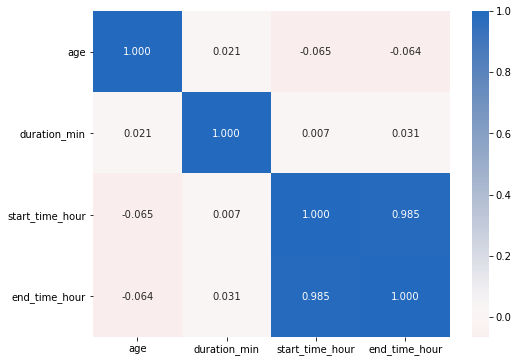

```python
# correlation matrices
plt.figure(figsize = [8, 6])
sb.heatmap(df1[numeric_vars].corr(), annot = True, fmt = '.3f',
           cmap = 'vlag_r', center = 0)
plt.yticks(rotation=0)
plt.show();
```

We'll also consider creating a plot matrix as a preliminary option to explore the relationship of our numeric variables. By default, PairGrid plots the same variables on the horizontal and vertical axes. On the diagonals, where the row and column variables match, a histogram is plotted. Off the diagonals, a scatterplot between the two variables is created.

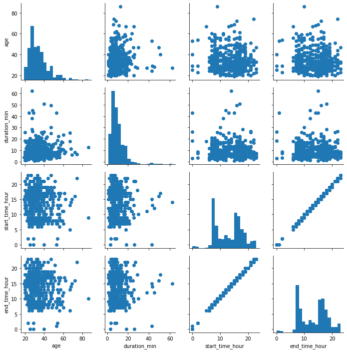

```python
# plot matrix: sample 500 trip data so that plots are clearer and
# they render faster
samples = np.random.choice(df1.shape[0], 500, replace = False)
trip_samp = df1.loc[samples,:]

g = sb.PairGrid(data = trip_samp, vars = numeric_vars)
g = g.map_diag(plt.hist, bins = 20)
g.map_offdiag(plt.scatter);
```

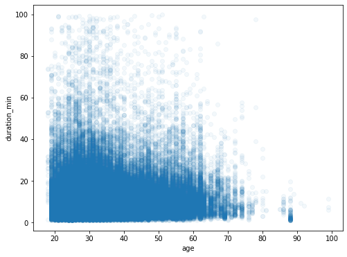

```python
# age vs duration
plt.figure(figsize = [8,6])
plt.scatter(data = df1, x = 'age', y = 'duration_min', alpha=1/20);
plt.xlabel('age')
plt.ylabel('duration_min');
```

Most of the data fall in the large blob between 20 and 80 years of age and 0 and 60 duration minutes. We'll crop the plot till those values and generate another scatter plot.

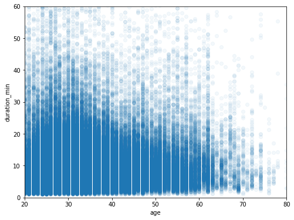

```python
# age vs duration
# apply axes limits
plt.figure(figsize = [8,6])
plt.xlim([20, 80])
plt.ylim([0, 60])
plt.scatter(data = df1, x = 'age', y = 'duration_min', alpha=1/20);
plt.xlabel('age')
plt.ylabel('duration_min');
```

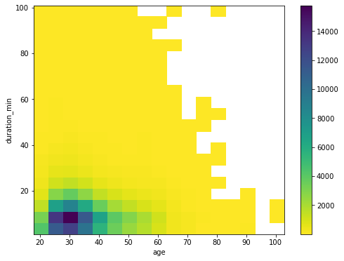

```python
# Specify bin edges
bins_x = np.arange(18, 99+5, 5)
bins_y = np.arange(1, 99+5, 5)
plt.figure(figsize = [8,6])
plt.hist2d(data = df1, x = 'age', y = 'duration_min', cmin=0.5, cmap='viridis_r', bins = [bins_x, bins_y])
plt.colorbar()
plt.xlabel('age')
plt.ylabel('duration_min');
```

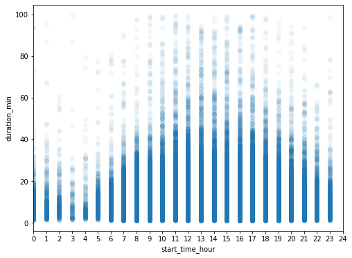

```python
# duration vs start time
plt.figure(figsize = [8,6])
plt.scatter(data = df1, x = 'start_time_hour', y = 'duration_min', alpha=1/20)
plt.xlim(0, 24)
plt.xticks(np.arange(0, 25, 1))
plt.xlabel('start_time_hour')
plt.ylabel('duration_min');
```

The correlation between duration_min and start_time_hour is not strong. For some unknown reason, members who rented GoBikes between 12 pm and 4 pm, tend to have used the bikes for a longer period of time.  
Now, let's explore the relationships between the three categorical variables.

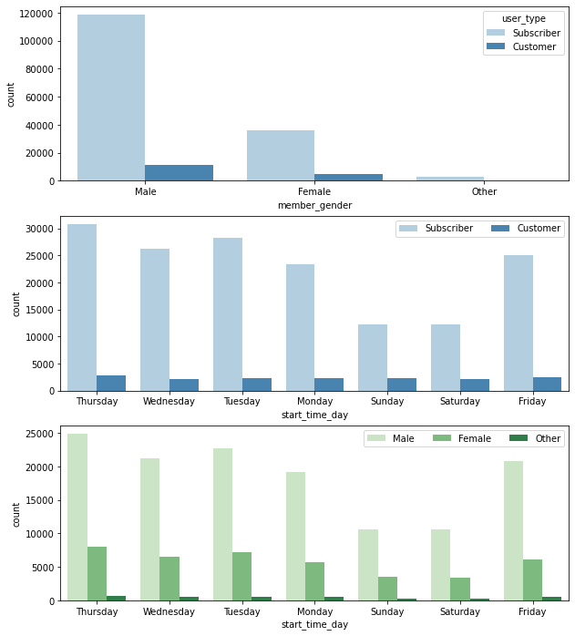

```python
# three subplots
plt.figure(figsize = [10, 12])

# subplot 1: user_type vs member_gender
plt.subplot(3, 1, 1)
sb.countplot(data = df1, x = 'member_gender', hue = 'user_type', palette = 'Blues')

# subplot 2: user_type vs start_time_day
ax = plt.subplot(3, 1, 2)
sb.countplot(data = df1, x = 'start_time_day', hue = 'user_type', palette = 'Blues')
ax.legend(ncol = 2) # re-arrange legend to reduce overlapping

# subplot 3: member_gender vs start_time_day
ax = plt.subplot(3, 1, 3)
sb.countplot(data = df1, x = 'start_time_day', hue = 'member_gender', palette = 'Greens')# use different color palette
ax.legend(loc = 1, ncol = 3) # re-arrange legend to remove overlapping

plt.show();
```

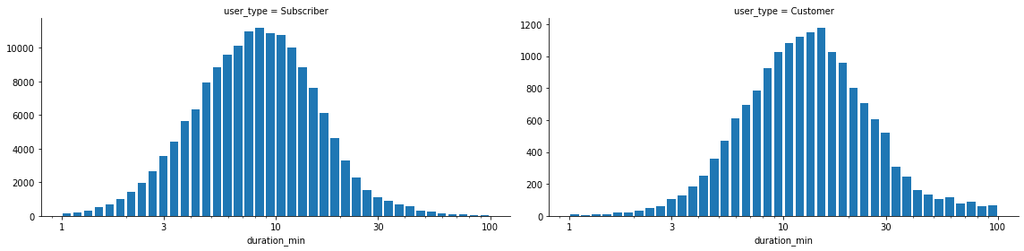

```python
# user trip pattern by duration histogram
g = sb.FacetGrid(data = df1, col='user_type', col_order = user_type_order, col_wrap = 2, height = 4, aspect = 2, sharey=False)
g.map(plt.hist, 'duration_min', bins = 10 ** np.arange(0, 2+0.05, 0.05), rwidth = 0.8).set(xscale = 'log');
ticks = [1, 3, 10, 30, 100]
labels = [i for i in ticks]
g.set(xticks = ticks, xticklabels = labels);
```

The above plots display that trips taken by the customers are usually longer compared to the subscribers.

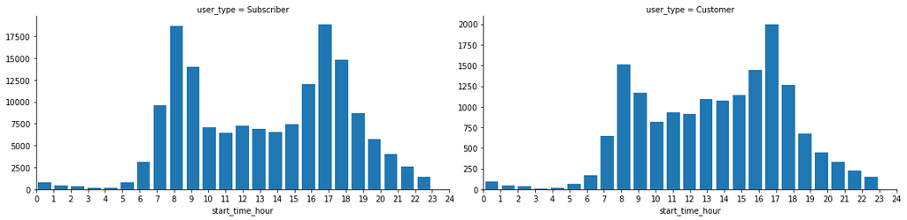

```python
# user trip pattern by hour (start time) histogram
# convert 'user_type' to an ordered type
user_type_order = df1.user_type.value_counts().index
# plot
g = sb.FacetGrid(data = df1, col='user_type', col_order = user_type_order, col_wrap = 2, height = 4, aspect = 2, sharey=False)
g.map(plt.hist, 'start_time_hour', bins = 24, rwidth = 0.8);
g.set(xlim=(0, 24), xticks=np.arange(0, 25, 1));
```

Both of the plots follow a similar distribution. The histograms are bimodal with spikes in 8 am and 5 pm, generally, same to the office hours. However, the count of trips are very low in the customer histogram compared to that of the subscribers. There are 89.2% subscribed members and 10.8% causal customers in the dataset, which is clearly reflected in their number of trips taken.

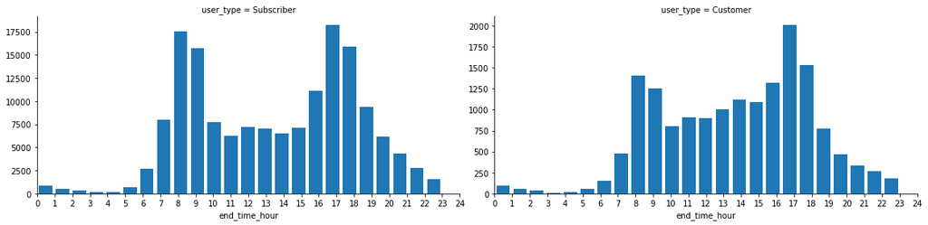

```python
# user trip pattern by hour (end time) histogram
# convert 'user_type' to an ordered type
user_type_order = df1.user_type.value_counts().index
# plot
g = sb.FacetGrid(data = df1, col='user_type', col_order = user_type_order, col_wrap = 2, height = 4, aspect = 2, sharey=False)
g.map(plt.hist, 'end_time_hour', bins = 24, rwidth = 0.8);
g.set(xlim=(0, 24), xticks=np.arange(0, 25, 1));
```

For end time of the bike rides, the peak hours are found 8 am to 9 am and 5 pm to 6 pm, for both user types. Both of the plots displays an increase in end time at 9 am and 6 pm, compared to the start time plots.

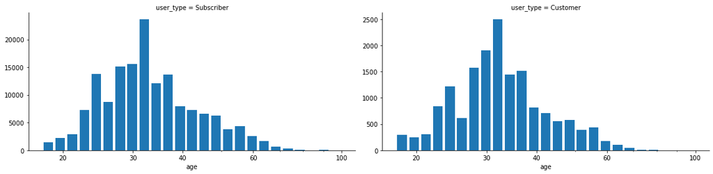

```python
# user vs age histogram
g = sb.FacetGrid(data = df1, col='user_type', col_order = user_type_order, col_wrap = 2, height = 4, aspect = 2, sharey=False)
g.map(plt.hist, 'age', bins = 10 ** np.arange(1.25, 2+0.03, 0.03), rwidth = 0.8).set(xscale = 'log');
ticks = [20, 30, 40, 60, 100]
labels = ['{}'.format(v) for v in ticks]
g.set(xticks = ticks, xticklabels = labels);
```

Age histograms present a similar shape for both of the user types. We'll have look into another plot type to decypher this relationship.

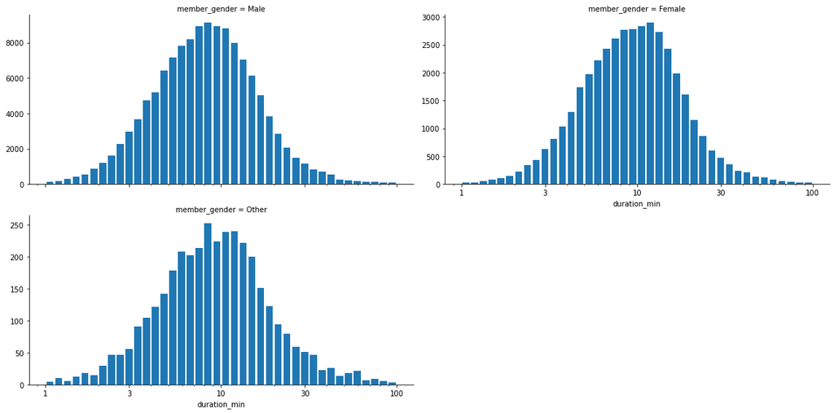

```python
# user trip pattern for gender by hour histogram
# convert 'member_gender' to an ordered type
member_gender_order = df1.member_gender.value_counts().index
# plot
g = sb.FacetGrid(data = df1, col='member_gender', col_order = member_gender_order, col_wrap = 2, height = 4, aspect = 2, sharey=False)
g.map(plt.hist, 'duration_min', bins = 10 ** np.arange(0, 2+0.05, 0.05), rwidth = 0.8).set(xscale = 'log');
ticks = [1, 3, 10, 30, 100]
labels = [i for i in ticks]
g.set(xticks = ticks, xticklabels = labels);
```

From the above graphs, it looks like female riders take longer trips compared to the males. More investigation will be conducted in the multivariate exploration section.

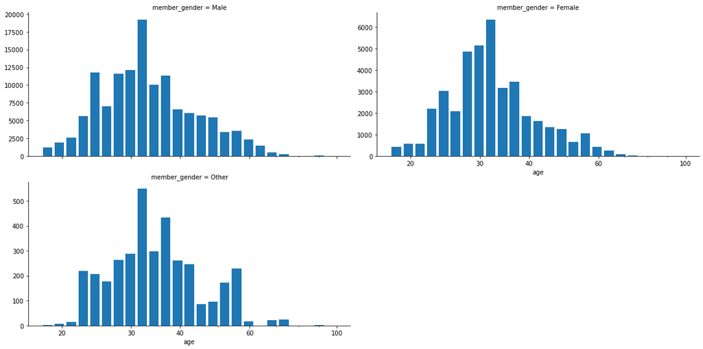

```python
# member_gender vs age
g = sb.FacetGrid(data = df1, col='member_gender', col_order = member_gender_order, col_wrap = 2, height = 4, aspect = 2, sharey=False)
g.map(plt.hist, 'age', bins = 10 ** np.arange(1.25, 2+0.03, 0.03), rwidth = 0.8).set(xscale = 'log');
ticks = [20, 30, 40, 60, 100]
labels = ['{}'.format(v) for v in ticks]
g.set(xticks = ticks, xticklabels = labels);
```

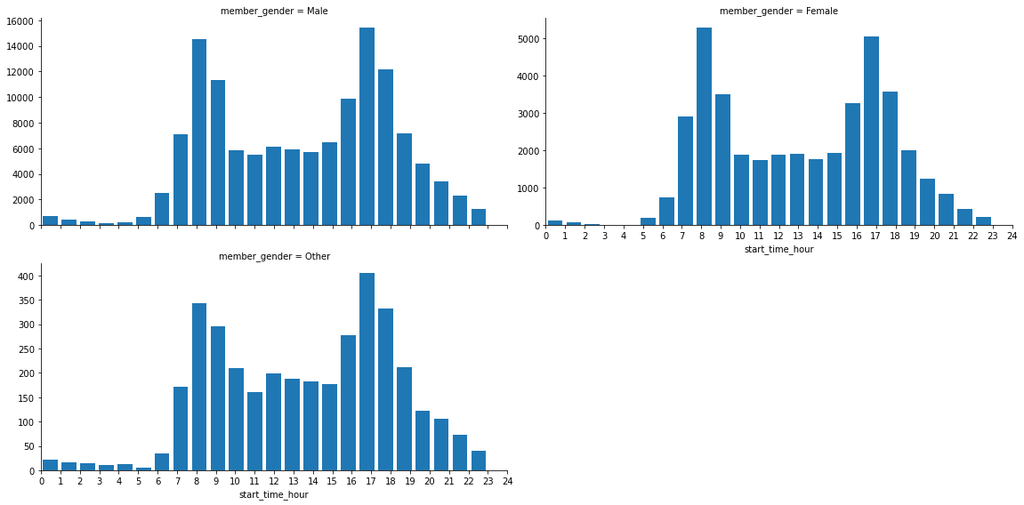

```python
# user trip pattern for gender by hour histogram
# convert 'member_gender' to an ordered type
member_gender_order = df1.member_gender.value_counts().index
# plot
g = sb.FacetGrid(data = df1, col='member_gender', col_order = member_gender_order, col_wrap = 2, height = 4, aspect = 2, sharey=False)
g.map(plt.hist, 'start_time_hour', bins = 24, rwidth = 0.8);
g.set(xlim=(0, 24), xticks=np.arange(0, 25, 1));
```

The above plots for member_gender and start_time_hour do not show any significant correlation.

## Multivariate Exploration

In this section of data analysis, I'll create plots of three or more variables to investigate the Ford GoBike data even further.  
The main thing I want to explore in this part is how trip duration is influenced by user type, user gender, and age. Trip duration can be also influenced by days and hours of the week when the users starts a trip. To understand the duration pattern, location of the GoBike stations will also come into play.  
We'll now use FacetGrid to create a multivariate plot with our primary features of interests—user, age, gender, and duration.

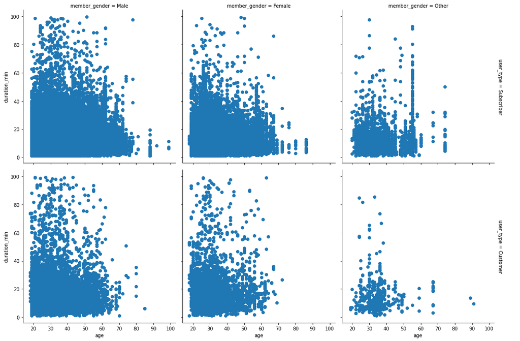

```python
# FacetGrid scatterplot for user_type, age, gender, and duration_min
g = sb.FacetGrid(data = df1, col = 'member_gender', col_order = member_gender_order, row = 'user_type', row_order = user_type_order, height = 5, aspect = 1,
                margin_titles = True)
g.map(plt.scatter, 'age', 'duration_min')

g.add_legend();
```

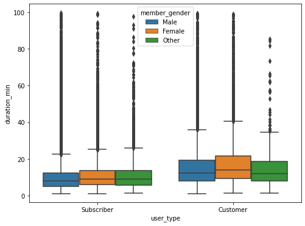

```python
# user, member gender, and duration boxplot
plt.figure(figsize = [8,6])
ax = sb.boxplot(x= 'user_type', y= 'duration_min', hue = 'member_gender', data= df1,
                 order=['Subscriber', 'Customer']);
```

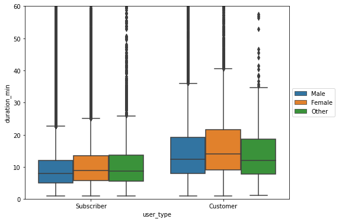

```python
# user, member gender, and duration boxplot
# apply y-limit to avoid some outliers
plt.figure(figsize = [8,6])
ax = sb.boxplot(x= 'user_type', y= 'duration_min', hue = 'member_gender', data= df1,
                 order=['Subscriber', 'Customer'])
plt.ylim(0, 60)
plt.legend(loc = 6, bbox_to_anchor = (1.0, 0.5));# legend to right of figure
```

We'll now generate a plot with user, gender, duration, and start time. We'll use catplot() to combine a boxplot() and a FacetGrid. This allows grouping within additional categorical variables. Using catplot() is safer than using FacetGrid directly, as it ensures synchronization of variable order across facets.

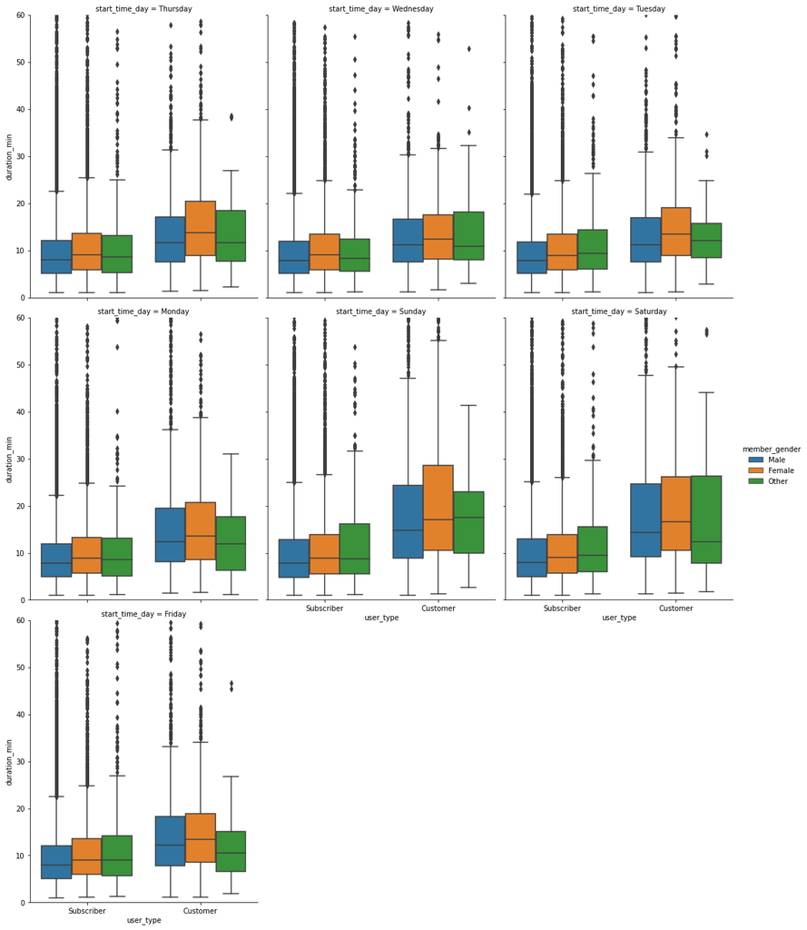

```python
# user, gender, duration, and start time day catplot
g = sb.catplot(x= 'user_type', y= 'duration_min', hue = 'member_gender',
                col='start_time_day',
                data= df1, kind= 'box',
                height= 6, aspect= .8, col_wrap = 3);
g.set(ylim = (0, 60));
```

Again, we observe that customers take longer trips than subscribers through out the week. We've already made an assumption to this in the user, gender, and duration exploration. Specially, on Saturdays and Sundays casual riders are found to bike longer than othe days of the week.  
Interestingly, female users are found to take long rides compared to males. Particulary, on the weekends, females are observed biking for long hours.

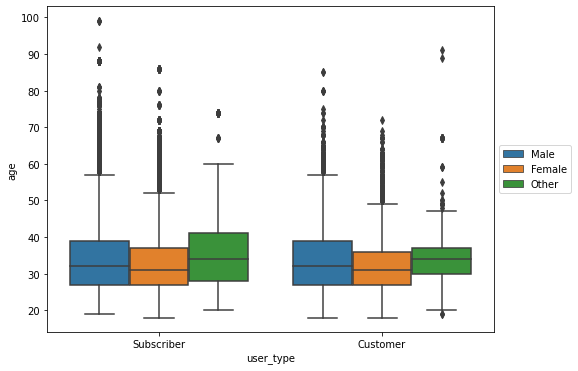

```python
# user, age, and member gender boxplot
plt.figure(figsize = [8,6])
ax = sb.boxplot(x= 'user_type', y= 'age', hue = 'member_gender', data= df1,
                 order=['Subscriber', 'Customer']);
plt.legend(loc = 6, bbox_to_anchor = (1.0, 0.5)); # legend to right of figure
```

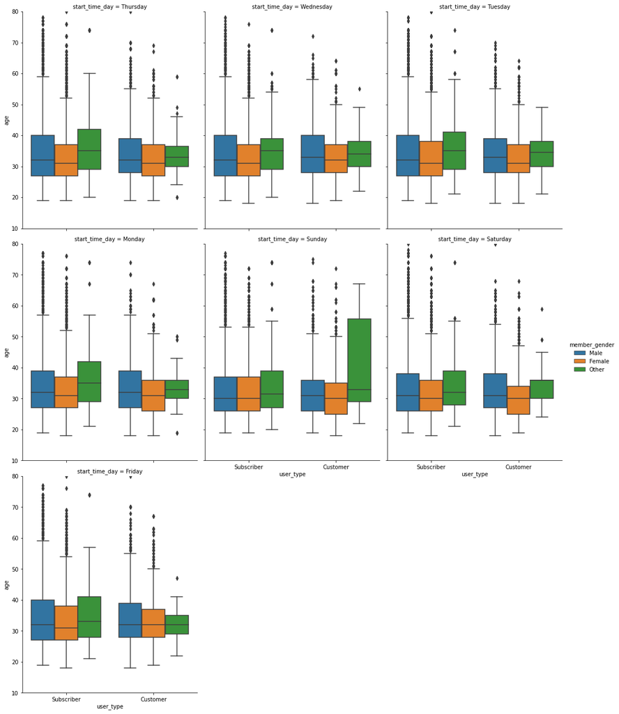

```python
# user, gender, age, and start time day catplot
g = sb.catplot(x= 'user_type', y= 'age', hue = 'member_gender',
                col='start_time_day',
                data= df1, kind= 'box',
                height= 6, aspect= .8, col_wrap = 3);
g.set(ylim = (10, 80));
```

```python
# data preparation
df1['trip_count'] = df1.groupby(['start_station_id'])['start_station_name'].transform('count')
print(df1['trip_count'].describe())
# check null values
print(df1['trip_count'].isnull().sum())
```

```
count    174370.000000
mean       1097.660853
std         846.312539
min           0.000000
25%         539.000000
50%         801.000000
75%        1417.000000
max        3640.000000
Name: trip_count, dtype: float64
0
```

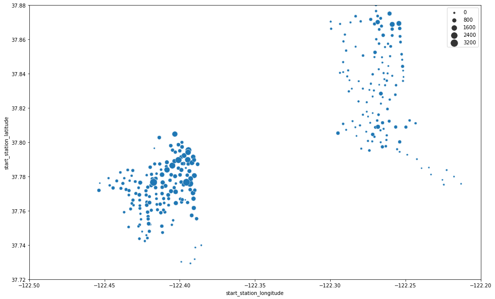

```python
# trip count by start station locations
# apply axis limit to get a better plot
plt.figure(figsize = [16,10])
sb.scatterplot( data = df1, x = 'start_station_longitude', y = 'start_station_latitude', size = 'trip_count', sizes = (10, 200))
plt.xlim(-122.50, -122.20)
plt.ylim(37.72, 37.88)
plt.legend();
```

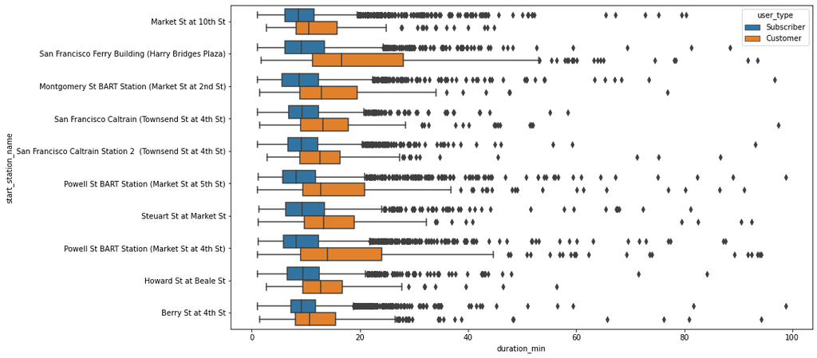

```python
# top ten start stations
top_start_station = df1.start_station_name.value_counts()[:10].index
# limit analysis to a dataframe containing only the top ten start stations
top_station_df = df1[df1.start_station_name.isin(top_start_station)].copy()
# user, start staions, and duration box plot
plt.figure(figsize = [14,8])
sb.boxplot(data = top_station_df, x='duration_min', y='start_station_name', hue = 'user_type', orient = 'h');
```

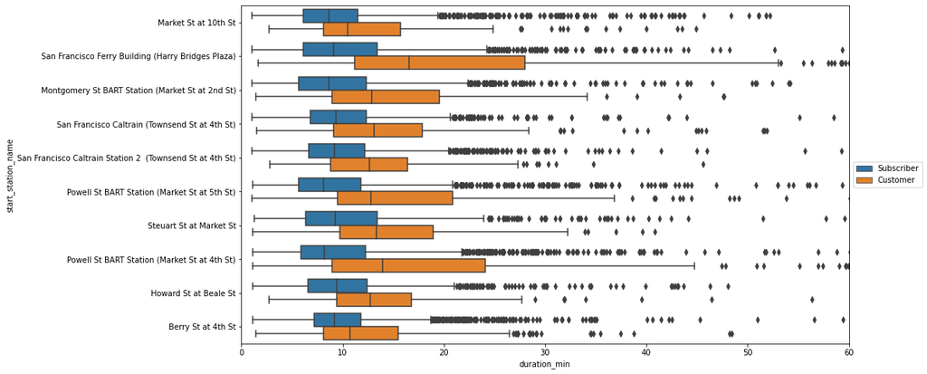

```python
# user, start stations, and duration box plot
# apply x limit
plt.figure(figsize = [14,8])
sb.boxplot(data = top_station_df, x='duration_min', y='start_station_name', hue = 'user_type', orient = 'h')
plt.xlim(0, 60)
plt.legend(loc = 6, bbox_to_anchor = (1.0, 0.5));# legend to right of figure;
```

For each of the top 10 start stations, the median duration of bike trips is longer for customers than subscribers. Also, for each station, the interquartile range, which approximates the trip length variability, is larger for the customers. This tells us that, typically, customers use the bikes longer, with greater variability in times, than subscribers. Trip durations in the stations are between 7 to 15 minutes for the subscribers and 8 to 30 minutes for the customers, ignoring the high-value outliers.

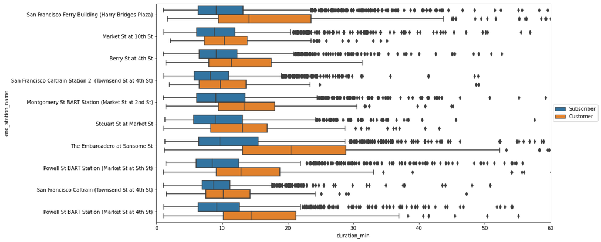

```python
# top ten end station name
top_end_station = df1['end_station_name'].value_counts()[:10].index
# limit analysis to a dataframe containing only the top ten end stations
top_end_station_df = df1[df1['end_station_name'].isin(top_end_station)].copy()
# user, end stations, and duration box plot
# apply x limit
plt.figure(figsize = [14,8])
sb.boxplot(data = top_end_station_df, x='duration_min', y='end_station_name', hue = 'user_type', hue_order = user_type_order, orient = 'h');
plt.xlim(0, 60)
plt.legend(loc = 6, bbox_to_anchor = (1.0, 0.5));# legend to right of figure;
```

A heatmap is generated to examine the mean duration for different days and hours. Instead of providing the original dataframe, we need to summarize the counts into a matrix that will then be plotted.

```python
# data preparation
df_mean = pd.DataFrame(df1.groupby(['start_time_day', 'start_time_hour']).mean()['duration_min'])
df_mean = df_mean.reset_index()
# convert the 'start_time_day' column from a plain object type into an ordered categorical type
start_time_day_classes = ['Monday', 'Tuesday', 'Wednesday', 'Thursday', 'Friday', 'Saturday', 'Sunday']
dayclasses = pd.api.types.CategoricalDtype(ordered=True, categories=start_time_day_classes)
df_mean.start_time_day = df_mean.start_time_day.astype(dayclasses);
```

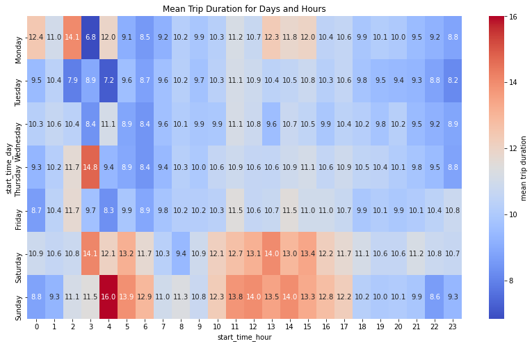

```python
# use DataFrame.pivot() to rearrange the data, to have days of the week on rows
df_mean = df_mean.pivot_table(values = 'duration_min', index = 'start_time_day', columns = 'start_time_hour')
# plot heatmap
plt.figure(figsize = [14,8])
sb.heatmap(df_mean, annot = True, fmt = '.1f', cbar_kws = {'label':'mean trip duration'}, cmap = 'coolwarm')
plt.title('Mean Trip Duration for Days and Hours');
```

Higher trip durations are observed during the weekends. The mean duration is highest on Saturdays and Sundays between 4 am and 5 pm, about 16 to 12 minutes. It can be assumed that, during weekends, users bike to places other than their works and study, and spend more time on the road. Among the working days, Mondays and Thursdays have higher trip durations, about 10 to 14 minutes. Although Mondays have the lowest trips taken (14.6%) among the weekdays, frequencies of 12 minutes trips are much higher. Our interpretation is that Mondays are likely the day when people are least organized as they return after the weekend and might take more time biking to workplaces. People get progressively readier to use the service during the week.

Now, to verify the observation that female riders take longer trips than the males, we are going to generat a point plot. A point plot represents an estimate of central tendency for a numeric variable by the position of scatter plot points and shows only the mean value.

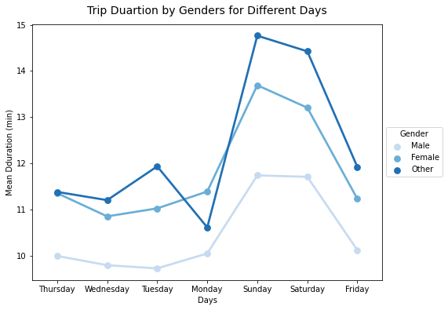

```python
# point plot
plt.figure(figsize = [8,6])
sb.pointplot(data = df1, x = 'start_time_day', y = 'duration_min', hue = 'member_gender', palette = 'Blues', ci = None)
plt.ylabel('Mean Dduration (min)')
plt.xlabel('Days')
plt.legend(title='Gender', loc = 6, bbox_to_anchor = (1.0, 0.5))
plt.title('Trip Duartion by Genders for Different Days', fontsize = 14, y = 1.02)
plt.show();
```

The above pointplot also displays that female riders are renting bikes for long durations. Particulary, on the weekends, females are observed biking for long hours. For the polished plot, we'll reorder the days of the week, for a better perception.

### Talk about some of the relationships you observed in this part of the investigation. Were there features that strengthened each other in terms of looking at your feature(s) of interest?

-**Mean Trip Duration for Days and Hours:** Higher trip durations are observed during the weekends. Among the working days, Mondays and Thursdays have higher trip durations, about 10 to 14 minutes.  
-**Trip Duration by Genders for Different Days:** It is verified in the multivariate exploration that female riders are renting bikes for long durations, particularly, on the weekends. -**Trip Duration for Different Stations:** For each of the top 10 start stations and end stations, the median duration of bike trips is longer for customers than subscribers.

### Were there any interesting or surprising interactions between features?

With the casual customers, a surprising number of old-aged people are found to bike on Sundays, about 68 years, which is the maximum value in the distribution. May be they just loved taking a joy ride on Sundays. San Franciso weather is generally cool in February, which did not prevent that age group from biking.  
Although Mondays have the lowest trips taken (14.6%) among the weekdays, frequencies of 12 minutes trips are much higher. Our interpretation is that Mondays are likely the day when people are least organized as they return after the weekend and might take more time biking to workplaces. People get progressively readier to use the service during the week.

```python
# create a cvs file for the master dataframe
df1.to_csv('df1.csv', index=False)
```

## References

[1]. https://en.wikipedia.org/wiki/Bay_Wheels  
[2] https://www.counterpointresearch.com/understanding-fords-gobike-user-dynamic/  
[3] https://www.transformca.org/landing-page/ford-gobike-model-equitable-bike-share-access-us-thanks-community-engagement